# Analysing differential hydrogen deuterium exchange mass spectrometry data

Oliver M. Crook

26 July 2021

#### Abstract

This vignette describes how to analyse a mass-spectrometry based hydrogen deuterium exchange experiment, in particular we focus on empirical Bayes functional models and visualisations.

#### Package

hdxstats 1.0

# 1 A well-defined HDX-MS experiment

This vignette describeds how to analyse time-resolved differential HDX-MS experiments. The key elements are at least two conditions i.e. apo + antibody, apo + small molecule or protein closed + protien open, etc. The experiment can be replicated, though if there are sufficient time points analysed (>=3) then occasionally signficant results can be obtained. The data provided should be centroid-centric data. This package does not yet support analysis straight from raw spectra. Typically this will be provided as a .csv from tools such as dynamiX or HDExaminer.

# 2 Main elements of the package

The package relies of Bioconductor infrastructure so that it integrates with other data types and can benefit from advantages in other fields of mass-spectrometry. There are package specific object, classes and methods but importantly there is reuse of classes found in quantitative proteomics data, mainly the `QFeatures` object which extends the `summarisedExperiment` class for mass spectrometry data. The focus of this package is on testing and visualisation of the testing results.

# 3 Data

We will begin with a structural variant experiment in which MHP and a structural variant were mixed in different proportions. HDX-MS was performed on these samples and we expect to see reproducible but subtle differences. We first load the data from the package and it is .csv format.

```r
MBPpath <- system.file("extdata", "MBP.csv", package = "hdxstats")
```

We can now read in the .csv file and have a quick look at the .csv.

```r
MBP <- read.csv(MBPpath)
head(MBP) # have a look
```

```
##   hx_sample pep_start pep_end pep_sequence pep_charge     d confidence  score
## 1       10%        19      30 VIWINGDKGYNG          2 2.120     medium 0.8686
## 2       10%        19      30 VIWINGDKGYNG          2 2.146     medium 0.8173
## 3       10%        19      30 VIWINGDKGYNG          2 2.143     medium 0.8839
## 4       10%        19      30 VIWINGDKGYNG          2    NA       <NA>     NA
## 5       10%        19      30 VIWINGDKGYNG          2    NA       <NA>     NA
## 6       10%        19      30 VIWINGDKGYNG          2    NA       <NA>     NA
##   hx_time time_unit replicate_cnt
## 1      30         s             1
## 2      30         s             2
## 3      30         s             3
## 4      30         s             4
## 5      30         s             5
## 6      30         s             6
```

```r
length(unique(MBP$pep_sequence)) # peptide sequences
```

```
## [1] 115
```

Let us have a quick visualisation of some the data so that we can see some of the features

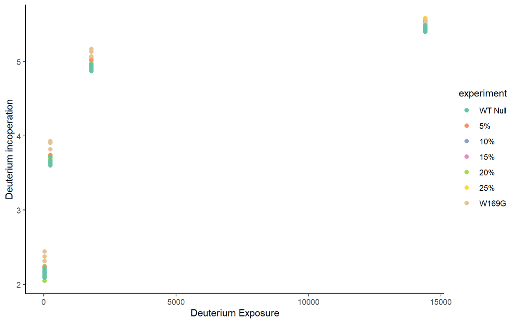

```r
filter(MBP, pep_sequence == unique(MBP$pep_sequence[1]), pep_charge == 2) %>%
    ggplot(aes(x = hx_time, y = d, group = factor(replicate_cnt),
               color = factor(hx_sample,
                              unique(MBP$hx_sample)[c(7,5,1,2,3,4,6)]))) +
    theme_classic() + geom_point(size = 2) +
    scale_color_manual(values = brewer.pal(n = 7, name = "Set2")) +
    labs(color = "experiment", x = "Deuterium Exposure", y = "Deuterium incoperation")
```

We can see that the units of the time dimension are in seconds and that Deuterium incoperation has been normalized into Daltons.

# 4 Parsing to an object of class QFeatures

Working from a .csv is likely to cause issues downstream. Indeed, we run the risk of accidently changing the data or corrupting the file in some way. Secondly, all .csvs will be formatted slightly different and so making extensible tools for these files will be inefficient. Furthermore, working with a generic class used in other mass-spectrometry fields can speed up analysis and adoption of new methods. We will work the class `QFeatures` from the `QFeatures` class as it is a powerful and scalable way to store quantitative mass-spectrometry data.

Firstly, the data is storted in long format rather than wide format. We first switch the data to wide format.

```r
MBP_wide <- pivot_wider(data.frame(MBP),
                        values_from = d,
                        names_from = c("hx_time", "replicate_cnt", "hx_sample"),
                        id_cols = c("pep_sequence", "pep_charge"))
head(MBP_wide)
```

```
## # A tibble: 6 x 198
##   pep_sequence pep_charge `30_1_10%` `30_2_10%` `30_3_10%` `30_4_10%` `30_5_10%`
##   <chr>             <int>      <dbl>      <dbl>      <dbl>      <dbl>      <dbl>
## 1 VIWINGDKGYNG          2      2.12       2.15       2.14          NA         NA
## 2 VIWINGDKGYN~          2      2.12       2.12       2.11          NA         NA
## 3 GDKGYNGLAEVG          3      0.552      0.555      0.553         NA         NA
## 4 LAEVGKKFEKD~          4      2.41       2.36       2.42          NA         NA
## 5 AEVGKKFEKDT~          4      0.458      0.425      0.573         NA         NA
## 6 TVEHPDKL              3      1.43       1.44       1.44          NA         NA
## # ... with 191 more variables: 30_6_10% <dbl>, 30_7_10% <dbl>, 240_1_10% <dbl>,
## #   240_2_10% <dbl>, 240_3_10% <dbl>, 240_4_10% <dbl>, 240_5_10% <dbl>,
## #   240_6_10% <dbl>, 240_7_10% <dbl>, 1800_1_10% <dbl>, 1800_2_10% <dbl>,
## #   1800_3_10% <dbl>, 1800_4_10% <dbl>, 1800_5_10% <dbl>, 1800_6_10% <dbl>,
## #   1800_7_10% <dbl>, 14400_1_10% <dbl>, 14400_2_10% <dbl>, 14400_3_10% <dbl>,
## #   14400_4_10% <dbl>, 14400_5_10% <dbl>, 14400_6_10% <dbl>, 14400_7_10% <dbl>,
## #   30_1_15% <dbl>, 30_2_15% <dbl>, 30_3_15% <dbl>, 30_4_15% <dbl>,
## #   30_5_15% <dbl>, 30_6_15% <dbl>, 30_7_15% <dbl>, 240_1_15% <dbl>,
## #   240_2_15% <dbl>, 240_3_15% <dbl>, 240_4_15% <dbl>, 240_5_15% <dbl>,
## #   240_6_15% <dbl>, 240_7_15% <dbl>, 1800_1_15% <dbl>, 1800_2_15% <dbl>,
## #   1800_3_15% <dbl>, 1800_4_15% <dbl>, 1800_5_15% <dbl>, 1800_6_15% <dbl>,
## #   1800_7_15% <dbl>, 14400_1_15% <dbl>, 14400_2_15% <dbl>, 14400_3_15% <dbl>,
## #   14400_4_15% <dbl>, 14400_5_15% <dbl>, 14400_6_15% <dbl>, 14400_7_15% <dbl>,
## #   30_1_20% <dbl>, 30_2_20% <dbl>, 30_3_20% <dbl>, 30_4_20% <dbl>,
## #   30_5_20% <dbl>, 30_6_20% <dbl>, 30_7_20% <dbl>, 240_1_20% <dbl>,
## #   240_2_20% <dbl>, 240_3_20% <dbl>, 240_4_20% <dbl>, 240_5_20% <dbl>,
## #   240_6_20% <dbl>, 240_7_20% <dbl>, 1800_1_20% <dbl>, 1800_2_20% <dbl>,
## #   1800_3_20% <dbl>, 1800_4_20% <dbl>, 1800_5_20% <dbl>, 1800_6_20% <dbl>,
## #   1800_7_20% <dbl>, 14400_1_20% <dbl>, 14400_2_20% <dbl>, 14400_3_20% <dbl>,
## #   14400_4_20% <dbl>, 14400_5_20% <dbl>, 14400_6_20% <dbl>, 14400_7_20% <dbl>,
## #   30_1_25% <dbl>, 30_2_25% <dbl>, 30_3_25% <dbl>, 30_4_25% <dbl>,
## #   30_5_25% <dbl>, 30_6_25% <dbl>, 30_7_25% <dbl>, 240_1_25% <dbl>,
## #   240_2_25% <dbl>, 240_3_25% <dbl>, 240_4_25% <dbl>, 240_5_25% <dbl>,
## #   240_6_25% <dbl>, 240_7_25% <dbl>, 1800_1_25% <dbl>, 1800_2_25% <dbl>,
## #   1800_3_25% <dbl>, 1800_4_25% <dbl>, 1800_5_25% <dbl>, 1800_6_25% <dbl>,
## #   1800_7_25% <dbl>, ...
```

We notice that there are many columns with `NA`s. The follow code chunk removes these columns.

```r
MBP_wide <- MBP_wide[, colSums(is.na(MBP_wide)) != nrow(MBP_wide)]
```

We also note that the colnames are not very informative. We are going to format in a very specific way so that later functions can automatically infer the design from the column names. We provide in the format X(time)rep(replicate)cond(condition)

```r
colnames(MBP_wide)[-c(1,2)]
```

```
##   [1] "30_1_10%"        "30_2_10%"        "30_3_10%"        "240_1_10%"
##   [5] "240_2_10%"       "240_3_10%"       "1800_1_10%"      "1800_2_10%"
##   [9] "1800_3_10%"      "14400_1_10%"     "14400_2_10%"     "14400_3_10%"
##  [13] "30_1_15%"        "30_2_15%"        "30_3_15%"        "240_1_15%"
##  [17] "240_2_15%"       "240_3_15%"       "1800_1_15%"      "1800_2_15%"
##  [21] "1800_3_15%"      "14400_1_15%"     "14400_2_15%"     "14400_3_15%"
##  [25] "30_1_20%"        "30_2_20%"        "30_3_20%"        "240_1_20%"
##  [29] "240_2_20%"       "240_3_20%"       "1800_1_20%"      "1800_2_20%"
##  [33] "1800_3_20%"      "14400_1_20%"     "14400_2_20%"     "14400_3_20%"
##  [37] "30_1_25%"        "30_2_25%"        "30_3_25%"        "240_1_25%"
##  [41] "240_2_25%"       "240_3_25%"       "1800_1_25%"      "1800_2_25%"
##  [45] "1800_3_25%"      "14400_1_25%"     "14400_2_25%"     "14400_3_25%"
##  [49] "30_1_5%"         "30_2_5%"         "30_3_5%"         "240_1_5%"
##  [53] "240_2_5%"        "240_3_5%"        "1800_1_5%"       "1800_2_5%"
##  [57] "1800_3_5%"       "14400_1_5%"      "14400_2_5%"      "14400_3_5%"
##  [61] "30_1_W169G"      "30_2_W169G"      "30_3_W169G"      "240_1_W169G"
##  [65] "240_2_W169G"     "240_3_W169G"     "1800_1_W169G"    "1800_2_W169G"
##  [69] "1800_3_W169G"    "14400_1_W169G"   "14400_2_W169G"   "14400_3_W169G"
##  [73] "30_1_WT Null"    "30_2_WT Null"    "30_3_WT Null"    "30_4_WT Null"
##  [77] "30_5_WT Null"    "30_6_WT Null"    "30_7_WT Null"    "240_1_WT Null"
##  [81] "240_2_WT Null"   "240_3_WT Null"   "240_4_WT Null"   "240_5_WT Null"
##  [85] "240_6_WT Null"   "240_7_WT Null"   "1800_1_WT Null"  "1800_2_WT Null"
##  [89] "1800_3_WT Null"  "1800_4_WT Null"  "1800_5_WT Null"  "1800_6_WT Null"
##  [93] "1800_7_WT Null"  "14400_1_WT Null" "14400_2_WT Null" "14400_3_WT Null"
##  [97] "14400_4_WT Null" "14400_5_WT Null" "14400_6_WT Null" "14400_7_WT Null"
```

```r
new.colnames <- gsub("0_", "0rep", paste0("X", colnames(MBP_wide)[-c(1,2)]))
new.colnames <- gsub("_", "cond", new.colnames)

# remove annoying % signs
new.colnames <- gsub("%", "", new.colnames)

# remove space (NULL could get confusing later and WT is clear)
new.colnames <- gsub(" .*", "", new.colnames)

new.colnames
```

```
##   [1] "X30rep1cond10"       "X30rep2cond10"       "X30rep3cond10"
##   [4] "X240rep1cond10"      "X240rep2cond10"      "X240rep3cond10"
##   [7] "X1800rep1cond10"     "X1800rep2cond10"     "X1800rep3cond10"
##  [10] "X14400rep1cond10"    "X14400rep2cond10"    "X14400rep3cond10"
##  [13] "X30rep1cond15"       "X30rep2cond15"       "X30rep3cond15"
##  [16] "X240rep1cond15"      "X240rep2cond15"      "X240rep3cond15"
##  [19] "X1800rep1cond15"     "X1800rep2cond15"     "X1800rep3cond15"
##  [22] "X14400rep1cond15"    "X14400rep2cond15"    "X14400rep3cond15"
##  [25] "X30rep1cond20"       "X30rep2cond20"       "X30rep3cond20"
##  [28] "X240rep1cond20"      "X240rep2cond20"      "X240rep3cond20"
##  [31] "X1800rep1cond20"     "X1800rep2cond20"     "X1800rep3cond20"
##  [34] "X14400rep1cond20"    "X14400rep2cond20"    "X14400rep3cond20"
##  [37] "X30rep1cond25"       "X30rep2cond25"       "X30rep3cond25"
##  [40] "X240rep1cond25"      "X240rep2cond25"      "X240rep3cond25"
##  [43] "X1800rep1cond25"     "X1800rep2cond25"     "X1800rep3cond25"
```

[output cut: 19 more lines]

We will now parse the data into an object of class `QFeatures`, we have provided a function to assist with this in the package. If you want to do this yourself use the `readQFeatures` function from the `QFeatures` package.

```r
MBPqDF <- parseDeutData(object = DataFrame(MBP_wide),
                        design = new.colnames,
                        quantcol = 3:102)
```

# 5 Heatmap visualisations of HDX data

To help us get used to the `QFeatures` we show how to generate a heatmap of these data from this object:

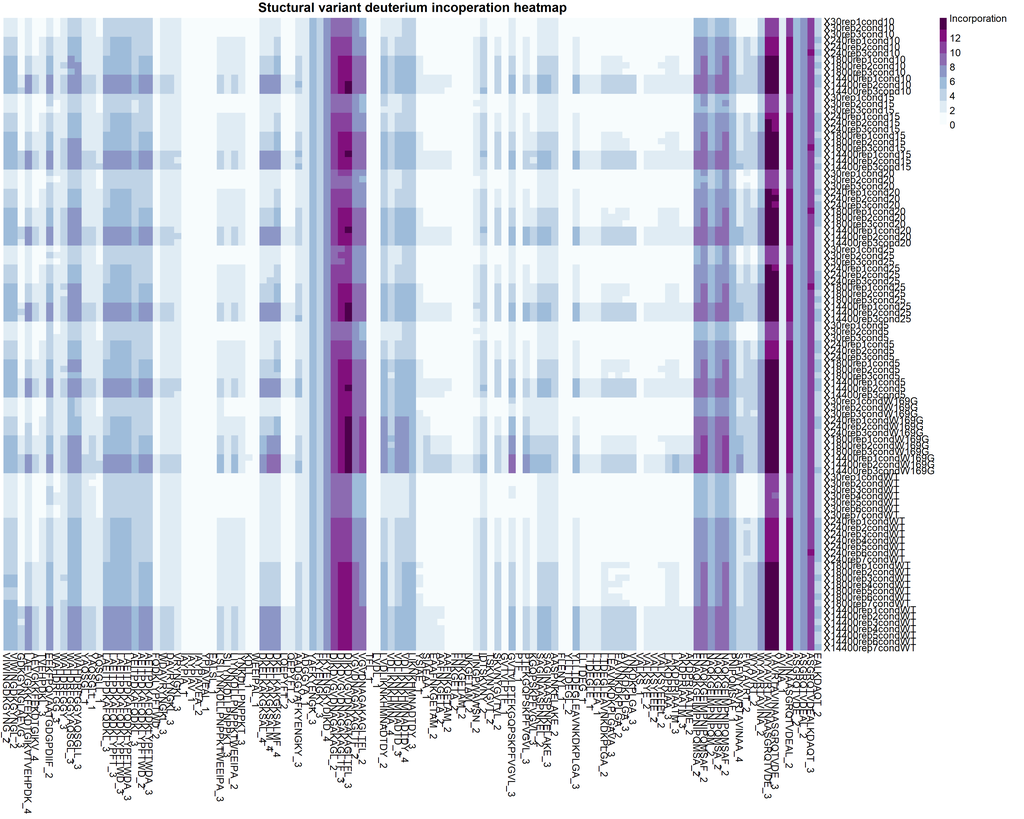

```r
pheatmap(t(assay(MBPqDF)),
         cluster_rows = FALSE,
         cluster_cols = FALSE,
         color = brewer.pal(n = 9, name = "BuPu"),
         main = "Stuctural variant deuterium incoperation heatmap",
         fontsize = 14,
         legend_breaks = c(0, 2, 4, 6, 8, 10, 12, max(assay(MBPqDF))),
         legend_labels = c("0", "2", "4", "6", "8","10", "12", "Incorporation"))
```

# 6 Functional data analysis of HDX-MS data

The `hdxstats` package uses an empirical Bayes functional approach to analyse the data. We explain this idea in steps so that we can get an idea of the approach. First we fit the parametric model to the data. This will allow us to explore the `HdxStatModel` class.

```r
res <- differentialUptakeKinetics(object = MBPqDF[,1:100], #provide a QFeature object
                                  feature = rownames(MBPqDF)[[1]][37], # which peptide to do we fit
                                  start = list(a = NULL, b = 0.0001,  d = NULL, p = 1)) # what are the starting parameter guesses
```

Here, we see the `HdxStatModel` class, and that a Functional Model was applied to the data and a total of 7 models were fitted.

```r
res
```

```
## Object of class "HdxStatModel"
## Method: Functional Model
## Fitted 7
```

The `nullmodel` and `alternative` slots of an instance of `HdxStatModel` provide the underlying fitted models. The `method` and `formula` slots provide vital information about what analysis was performed. The `vis` slot provides a `ggplot` object so that we can visualise the functional fits.

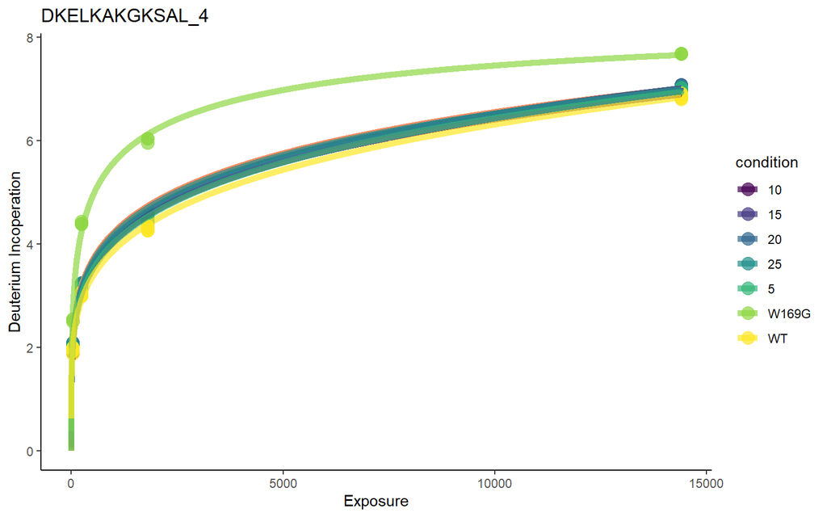

```r
res@vis
```

Since this is a ggplot object, we can customise in the usual grammatical ways.

```r
res@vis + scale_color_manual(values = brewer.pal(n = 8, name = "Set2"))
```

```
## which will replace the existing scale.
```

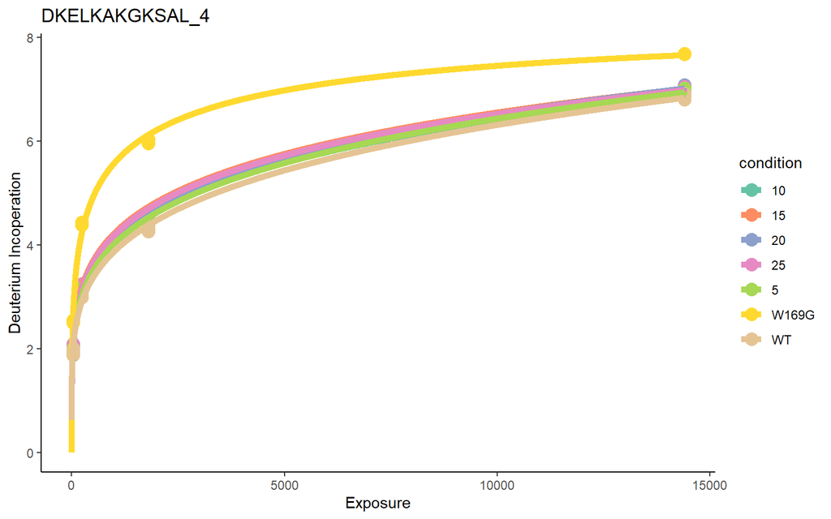

A number of standard methods are available and can be applied to a `HdxStatModels`, these extend the usual `base` stats methods. These include

1. `anova`: An analysis of variance
2. `logLik`: The log-likelihood of all the fitted models
3. `residuals`: The residuals for the fitted models
4. `vcov`: The variance-covariance matrix between parameters of the models
5. `likRatio`: The likelihood ratio between null and alternative models
6. `wilk`: Applies wilk’s theorem to obtain a p-value from the liklihood ratio
7. `coef`: The fitted model coefficients
8. `deviance`: The deviance of the fitted models
9. `summary`: The statistical summary of the models.

```r
anova(res)
```

```
## Analysis of Variance Table
##
## Model 1: value ~ a * (1 - exp(-b * (timepoint)^p)) + d
## Model 2: value ~ a * (1 - exp(-b * (timepoint)^p)) + d
## Model 3: value ~ a * (1 - exp(-b * (timepoint)^p)) + d
## Model 4: value ~ a * (1 - exp(-b * (timepoint)^p)) + d
## Model 5: value ~ a * (1 - exp(-b * (timepoint)^p)) + d
## Model 6: value ~ a * (1 - exp(-b * (timepoint)^p)) + d
## Model 7: value ~ a * (1 - exp(-b * (timepoint)^p)) + d
## Model 8: value ~ a * (1 - exp(-b * (timepoint)^p)) + d
##   Res.Df Res.Sum Sq  Df  Sum Sq F value    Pr(>F)
## 1     96    14.0906
## 2      8     0.0786  88 14.0120 16.2033 0.0001427 ***
## 3      8     0.0964   0  0.0000
## 4      8     0.0619   0  0.0000
## 5      8     0.0435   0  0.0000
## 6      8     0.0889   0  0.0000
## 7      8     0.1386   0  0.0000
## 8     24     0.1983 -16 -0.0597  0.2155 0.9955920
## ---
## Signif. codes:  0 '***' 0.001 '**' 0.01 '*' 0.05 '.' 0.1 ' ' 1
```

```r
logLik(res)
```

```
##       null       alt1       alt2       alt3       alt4       alt5       alt6
## -43.910623  13.141385  11.918525  14.576956  16.697584  12.405724   9.739545
##       alt7
##  29.570914
```

```r
residuals(res)
```

```
## $null
##   [1] -0.1087176969 -0.2047176969 -0.1207176969 -0.0461908281 -0.0721908281
##   [6] -0.0101908281 -0.2657724078 -0.2317724078 -0.3037724078 -0.0460995039
##  [11] -0.1310995039 -0.1080995039 -0.0707176969 -0.0977176969 -0.1837176969
##  [16] -0.0121908281  0.0208091719  0.0208091719 -0.2757724078 -0.1597724078
##  [21] -0.1947724078  0.0349004961 -0.0130995039  0.0619004961 -0.0157176969
##  [26] -0.1057176969 -0.0147176969  0.0318091719  0.0178091719  0.0498091719
##  [31] -0.1717724078 -0.1347724078 -0.1887724078  0.0049004961  0.0679004961
##  [36]  0.0009004961 -0.0247176969 -0.0757176969 -0.1397176969  0.0018091719
##  [41]  0.0338091719  0.0568091719 -0.0857724078 -0.1017724078 -0.0847724078
##  [46] -0.0630995039 -0.0120995039  0.0369004961 -0.1137176969 -0.1017176969
##  [51] -0.1047176969 -0.0371908281 -0.0691908281 -0.0251908281 -0.2237724078
##  [56] -0.2737724078 -0.3757724078 -0.0840995039  0.0069004961 -0.0650995039
##  [61]  0.3902823031  0.4472823031  0.4262823031  1.2018091719  1.2488091719
##  [66]  1.1888091719  1.3082275922  1.2262275922  1.3102275922  0.6789004961
##  [71]  0.6759004961  0.6619004961 -0.1687176969 -0.1247176969 -0.1197176969
##  [76] -0.1237176969 -0.1107176969 -0.2357176969 -0.1797176969 -0.1191908281
##  [81] -0.2011908281 -0.1491908281 -0.1421908281 -0.1591908281 -0.1241908281
##  [86] -0.1971908281 -0.4717724078 -0.4527724078 -0.3827724078 -0.4057724078
##  [91] -0.4807724078 -0.4207724078 -0.4237724078 -0.2140995039 -0.1950995039
##  [96] -0.1260995039 -0.1060995039 -0.1350995039 -0.1900995039 -0.0950995039
## attr(,"label")
## [1] "Residuals"
##
## $alt1
##  [1] -0.009322888 -0.105322888 -0.021322888  0.106288152  0.080288152
##  [6]  0.142288152 -0.082503400 -0.048503400 -0.120503400  0.070940082
## [11] -0.014059918  0.008940082
## attr(,"label")
## [1] "Residuals"
##
## $alt2
##  [1] -0.003592973 -0.030592973 -0.116592973  0.099392618  0.132392618
##  [6]  0.132392618 -0.157218529 -0.041218529 -0.076218529  0.031475396
## [11] -0.016524604  0.058475396
## attr(,"label")
## [1] "Residuals"
##
## $alt3
##  [1] -1.088794e-02 -1.008879e-01 -9.887937e-03  9.663941e-02  8.263941e-02
```

[output cut: 18 more lines]

```
## $alt6
##  [1] -0.10759976 -0.05059976 -0.07159976  0.14770160  0.19470160  0.13470160
##  [7] -0.08134445 -0.16334445 -0.07934445  0.03046397  0.02746397  0.01346397
## attr(,"label")
## [1] "Residuals"
##
## $alt7
##  [1] -0.065672255 -0.021672255 -0.016672255 -0.020672255 -0.007672255
##  [6] -0.132672255 -0.076672255  0.151605211  0.069605211  0.121605211
## [11]  0.128605211  0.111605211  0.146605211  0.073605211 -0.118700059
## [16] -0.099700059 -0.029700059 -0.052700059 -0.127700059 -0.067700059
## [21] -0.070700059 -0.039361618 -0.020361618  0.048638382  0.068638382
## [26]  0.039638382 -0.015361618  0.079638382
## attr(,"label")
## [1] "Residuals"
```

```r
vcov(res)
```

```
## $nullvcov
##             a            b            d            p
## a 51845.96221 -40.30049781 -564.4474104 -55.77619164
## b   -40.30050   0.03142629    0.4338129   0.04312009
## d  -564.44741   0.43381288    6.3931296   0.61872995
## p   -55.77619   0.04312009    0.6187300   0.06056114
##
## $altvcov
## $altvcov[[1]]
##               a             b             d             p
## a 10444961.9522 -703.03358414 -6015.6075822 -673.25122429
## b     -703.0336    0.04732351     0.4042563    0.04528165
## d    -6015.6076    0.40425632     3.5873568    0.39401021
## p     -673.2512    0.04528165     0.3940102    0.04372867
##
## $altvcov[[2]]
##               a             b             d             p
## a 19354023.7673 -1.007942e+03 -8697.0872334 -991.86073521
## b    -1007.9424  5.249590e-02     0.4522867    0.05162067
## d    -8697.0872  4.522867e-01     4.0499729    0.45304650
## p     -991.8607  5.162067e-02     0.4530465    0.05122726
##
## $altvcov[[3]]
##              a             b             d             p
## a 4552740.6012 -368.82485376 -3266.9390972 -383.37329769
## b    -368.8249    0.02988215     0.2641473    0.03102956
## d   -3266.9391    0.26414732     2.4323079    0.27978712
## p    -383.3733    0.03102956     0.2797871    0.03254357
##
## $altvcov[[4]]
##             a            b             d             p
## a 6864.520437 -6.441906003 -106.11073025 -10.722778012
## b   -6.441906  0.006083713    0.09794035   0.009982697
## d -106.110730  0.097940348    1.71150119   0.169125295
## p  -10.722778  0.009982697    0.16912530   0.016917195
##
## $altvcov[[5]]
##               a             b             d             p
## a 13387360.6872 -647.49396247 -5681.5798697 -770.53586039
## b     -647.4940    0.03131890     0.2743356    0.03723897
## d    -5681.5799    0.27433561     2.5117403    0.33309240
## p     -770.5359    0.03723897     0.3330924    0.04473613
##
## $altvcov[[6]]
##            a            b           d            p
## a  2.9829656  0.135178730 -2.15569792 -0.142999918
## b  0.1351787  0.006239611 -0.09913449 -0.006522984
## d -2.1556979 -0.099134493  1.59005367  0.103073198
## p -0.1429999 -0.006522984  0.10307320  0.006924275
##
## $altvcov[[7]]
##               a             b             d             p
## a 1889281.98027 -99.552456909 -927.27826196 -156.27693378
## b     -99.55246   0.005246328    0.04874778    0.00822604
## d    -927.27826   0.048747779    0.47799148    0.07837851
## p    -156.27693   0.008226040    0.07837851    0.01305747
```

```r
likRatio(res)
```

```
##    logLR
## 303.9225
```

```r
wilk(res)
```

```
##      p-value
## 2.718741e-50
```

```r
coef(res)
```

```
##               a           b          d         p
## null  32.051041 0.033332159 0.00000000 0.2091504
## alt1 117.106163 0.008312519 0.05395662 0.2067844
## alt2 132.034758 0.007210028 0.10762327 0.2097946
## alt3 103.291695 0.008900141 0.22258216 0.2124511
## alt4  27.362931 0.037597301 0.00000000 0.2150760
## alt5 123.828766 0.006296249 0.37946849 0.2253357
## alt6   8.320486 0.130807205 0.00000000 0.3096142
## alt7 103.413551 0.005789148 0.61994061 0.2476660
```

```r
deviance(res)
```

```
##        null        alt1        alt2        alt3        alt4        alt5
## 14.09056723  0.07861433  0.09638630  0.06188589  0.04346058  0.08886908
##        alt6        alt7
##  0.13859104  0.19831856
```

```r
summary(res)
```

```
## $null
##
## Formula: value ~ a * (1 - exp(-b * (timepoint)^p)) + d
##
## Parameters:
##    Estimate Std. Error t value Pr(>|t|)
## a  32.05104  227.69708   0.141    0.888
## b   0.03333    0.17727   0.188    0.851
## d   0.00000    2.52846   0.000    1.000
## p   0.20915    0.24609   0.850    0.398
##
## Residual standard error: 0.3831 on 96 degrees of freedom
##
## Number of iterations to convergence: 53
## Achieved convergence tolerance: 1.49e-08
##
##
## $alt1
##
## Formula: value ~ a * (1 - exp(-b * (timepoint)^p)) + d
##
## Parameters:
##    Estimate Std. Error t value Pr(>|t|)
## a 1.171e+02  3.232e+03   0.036    0.972
## b 8.313e-03  2.175e-01   0.038    0.970
## d 5.396e-02  1.894e+00   0.028    0.978
## p 2.068e-01  2.091e-01   0.989    0.352
##
## Residual standard error: 0.09913 on 8 degrees of freedom
##
## Number of iterations till stop: 98
## Achieved convergence tolerance: 1.49e-08
## Reason stopped: Number of calls to `fcn' has reached or exceeded `maxfev' == 500.
##
##
## $alt2
##
## Formula: value ~ a * (1 - exp(-b * (timepoint)^p)) + d
##
## Parameters:
```

[output cut: 88 more lines]

```
##
## Parameters:
##    Estimate Std. Error t value Pr(>|t|)
## a 1.034e+02  1.375e+03   0.075   0.9407
## b 5.789e-03  7.243e-02   0.080   0.9370
## d 6.199e-01  6.914e-01   0.897   0.3788
## p 2.477e-01  1.143e-01   2.167   0.0403 *
## ---
## Signif. codes:  0 '***' 0.001 '**' 0.01 '*' 0.05 '.' 0.1 ' ' 1
##
## Residual standard error: 0.0909 on 24 degrees of freedom
##
## Number of iterations till stop: 95
## Achieved convergence tolerance: 1.49e-08
## Reason stopped: Number of calls to `fcn' has reached or exceeded `maxfev' == 500.
```

# 7 Analysis of a typical HDX-MS experiment

We have seen the basic aspects of our functional modelling approach. We now wish to roll out our method across all peptides in the experiment. The `fitUptakeKinetics` function allows us to apply our modelling approach across all the peptide in the experiment. We need to provide a `QFeatures` object and the features for which we are fitting the model. The design will be extracted from the column names or you can provide a design yourself. The parameter initilisation should also be provided. Sometimes the model can’t be fit on the kinetics. This is either because there is not enough data or through lack of convergence. An error will be reported in these cases but this should not perturb the user. You may wish to try a few starting values if there excessive models that fail fitting.

```r
res <- fitUptakeKinetics(object = MBPqDF[,c(1:24)],
                         feature = rownames(MBPqDF[,c(1:24)])[[1]],
                         start = list(a = NULL, b = 0.001,  d = NULL, p = 1))
```

[output not shown]

The code chunk above returns a class `HdxStatModels` indicating that a number of models for peptide have been fit. This is simply a holder for a list of `HdxStatModel` instances.

```r
res
```

```
## Object of class "HdxStatModels"
## Number of models 104
```

We can easily examine indivual fits by going to the underyling `HdxStatModel` class:

```r
res@statmodels[[1]]@vis + scale_color_manual(values = brewer.pal(n = 2, name = "Set2"))
```

```
## which will replace the existing scale.
```

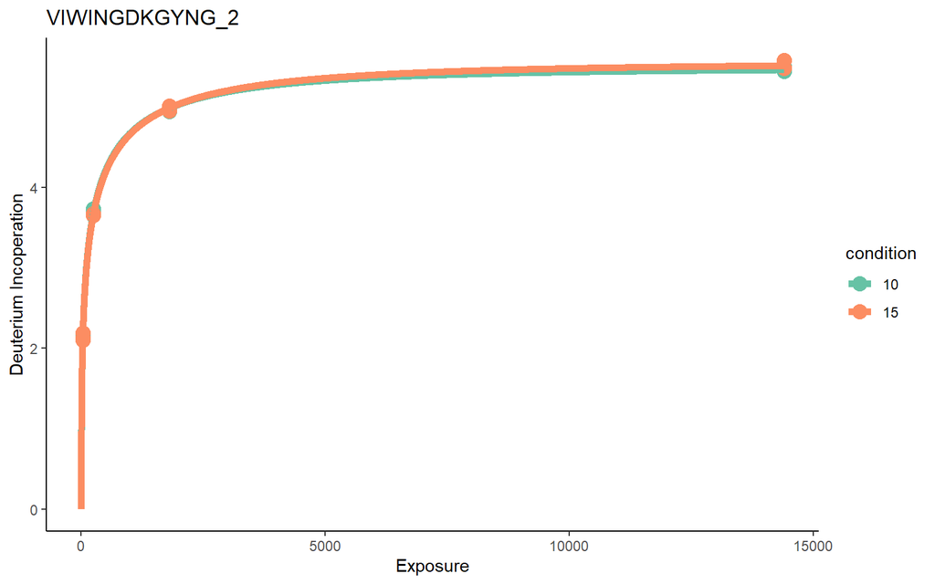

We now wish to apply statistical analysis to these fitted curves. Our approach is an empirical Bayes testing procedure, which borrows information across peptides to stablise variance estimates. Here, we need to provide the original data that was analysed and the `HdxStatModels` class. The following code chunk returns an object of class `HdxStatRes`. This object tell us that statistical analysis was performed using our Functional model.

```r
out <- processFunctional(object = MBPqDF[,1:24], params = res)
out
```

```
## Object of class "HdxStatRes"
## Analysed using Functional model
```

The main slot of interest is the `results` slot which returns quantities of interest such as `p-values` and `fdr` corrected p-values because of multiple testing. The following is the `DataFrame` of interest.

```r
out@results
```

```
## DataFrame with 104 rows and 8 columns
##                           Fstat.Fstat Fstat.numerator Fstat.denomenator
##                                <list>          <list>            <list>
## VIWINGDKGYNG_2                0.70875      0.00109168        0.00154029
## VIWINGDKGYNGL_2             0.0329098     6.18014e-05         0.0018779
## GDKGYNGLAEVG_3               0.980103      0.00129713        0.00132346
## LAEVGKKFEKDTGIKVTVEHPDK_4    0.809885      0.00117025        0.00144496
## AEVGKKFEKDTGIKV_4            0.806449      0.00140588        0.00174329
## ...                               ...             ...               ...
## NAQKGEIMPNIPQM_2              1.74802      0.00425775        0.00243575
## NAQKGEIMPNIPQMSA_2            5.50307        0.013198        0.00239829
## NAQKGEIMPNIPQMSAF_2           7.06683      0.00431371       0.000610416
## PNIPQMSAF_1                  0.905875      0.00277575        0.00306417
## SAFWYAVRTAVINAA_4            0.364667      0.00215098        0.00589847
##                                pvals       fdr ebayes.pvals ebayes.fdr
##                            <numeric> <numeric>    <numeric>  <numeric>
## VIWINGDKGYNG_2              0.597687  0.999959     0.584744   0.999952
## VIWINGDKGYNGL_2             0.997692  0.999959     0.997487   0.999952
## GDKGYNGLAEVG_3              0.445918  0.999959     0.438269   0.999952
## LAEVGKKFEKDTGIKVTVEHPDK_4   0.536935  0.999959     0.525822   0.999952
## AEVGKKFEKDTGIKV_4           0.538920  0.999959     0.520828   0.999952
## ...                              ...       ...          ...        ...
## NAQKGEIMPNIPQM_2          0.18879415 0.6333739   0.16773031  0.6229983
## NAQKGEIMPNIPQMSA_2        0.00554988 0.0443991   0.00430216  0.0394778
## NAQKGEIMPNIPQMSAF_2       0.00177921 0.0231297   0.00269021  0.0378613
## PNIPQMSAF_1               0.48384985 0.9999586   0.44999538  0.9999517
## SAFWYAVRTAVINAA_4         0.83017683 0.9999586   0.80620115  0.9999517
##                           fitcomplete
##                             <integer>
## VIWINGDKGYNG_2                      1
## VIWINGDKGYNGL_2                     2
## GDKGYNGLAEVG_3                      3
## LAEVGKKFEKDTGIKVTVEHPDK_4           4
## AEVGKKFEKDTGIKV_4                   5
## ...                               ...
## NAQKGEIMPNIPQM_2                  100
## NAQKGEIMPNIPQMSA_2                101
## NAQKGEIMPNIPQMSAF_2               102
## PNIPQMSAF_1                       103
## SAFWYAVRTAVINAA_4                 104
```

We can now examine the peptides for which the false discovery rate is less than 0.05

```r
which(out@results$ebayes.fdr < 0.05)
```

```
##    AADGGYAFKYENGKY_3           FKYENGKY_3   DIKDVGVDNAGAKAGL_2
##                   42                   45                   47
##     VGVDNAGAKAGLTF_2        VDLIKNKHMNA_4     VDLIKNKHMNADTD_3
##                   50                   55                   56
##    VDLIKNKHMNADTDY_4           IDTSKVNY_2         AKDPRIAATM_3
##                   57                   68                   96
## ENAQKGEIMPNIPQMSAF_2   NAQKGEIMPNIPQMSA_2  NAQKGEIMPNIPQMSAF_2
##                   99                  101                  102
```

Let us visualise some of these examples:

[figure not shown]

```r
res@statmodels[[42]]@vis + res@statmodels[[45]]@vis
```

As we can see our model has picked up some subtle differences, we can further visualise these using a forest plot. We can see the the functions are very similar as the parameters are almost identical `(a,b,p,d)`. However, we can see that the deuterium differences are lower in 10% structural variant condition.

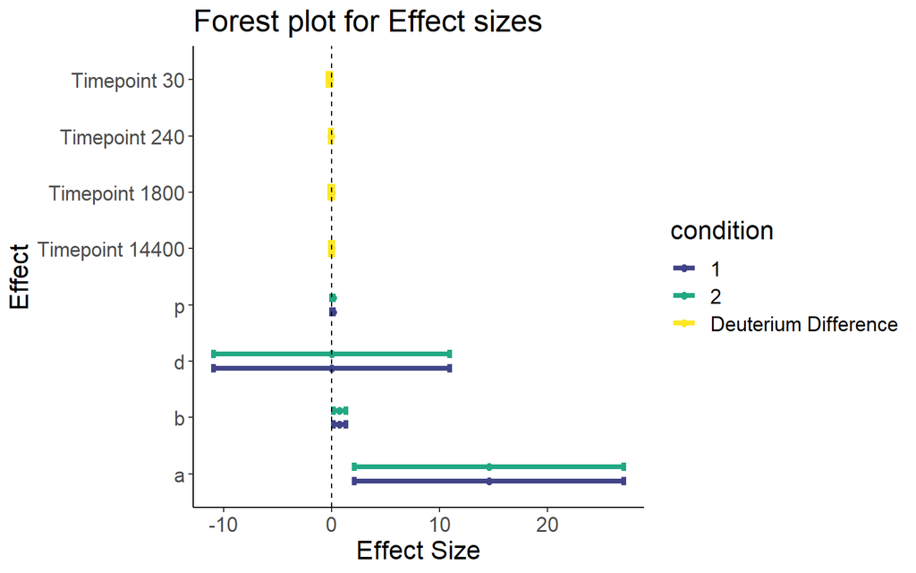

```r
fp <- forestPlot(params = res@statmodels[[42]])
```

```r
knitr::kable(fp$data)
```

|  | Estimate | confL | confU | rownames | condition |
| --- | --- | --- | --- | --- | --- |
| a | 14.5886568 | 2.0924780 | 27.0848357 | a | 1 |
| b | 0.7379218 | 0.1522014 | 1.3236423 | b | 1 |
| d | 0.0000000 | -10.9478563 | 10.9478563 | d | 1 |
| p | 0.1076040 | 0.0256683 | 0.1895398 | p | 1 |
| a1 | 14.5886568 | 2.0924780 | 27.0848357 | a | 2 |
| b1 | 0.7379218 | 0.1522014 | 1.3236423 | b | 2 |
| d1 | 0.0000000 | -10.9478563 | 10.9478563 | d | 2 |
| p1 | 0.1076040 | 0.0256683 | 0.1895398 | p | 2 |
| 1 | -0.1683333 | -0.3086635 | -0.0280032 | Timepoint 30 | Deuterium Difference |
| 2 | -0.0333333 | -0.0854565 | 0.0187898 | Timepoint 240 | Deuterium Difference |
| 3 | -0.0166667 | -0.1428652 | 0.1095319 | Timepoint 1800 | Deuterium Difference |
| 4 | -0.0116667 | -0.1310199 | 0.1076866 | Timepoint 14400 | Deuterium Difference |

Let’s us now have a look a situation where the changes are more dramatic.

```r
res_wt <- fitUptakeKinetics(object = MBPqDF[, c(61:100)],
                            feature = rownames(MBPqDF[, c(61:100)])[[1]],
                            start = list(a = NULL, b = 0.001,  d = NULL, p = 1))
```

[output not shown]

[output cut: 14 more lines]

[output not shown]

```r
out_wt <- processFunctional(object = MBPqDF[, c(61:100)], params = res_wt)
```

We can visualise some of the result and generate plots.

[figure not shown]

[figure not shown]

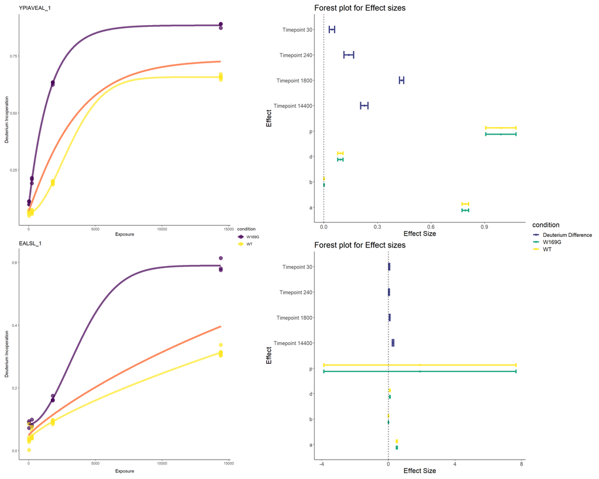

```r
res_wt@statmodels[[27]]@vis/res_wt@statmodels[[28]]@vis + plot_layout(guides = "collect")|(forestPlot(params = res_wt@statmodels[[27]], condition = c("WT", "W169G"))/forestPlot(params = res_wt@statmodels[[28]], condition = c("WT", "W169G")) + plot_layout(guides = "collect")) +
    plot_annotation(tag_levels = 'a') +  plot_layout(widths = c(1, 1))
```

# An epitope mapping experiment

We now describe the analysis of an epitope mapping experiment. Here, the data analysis is more challenging, since only 1 replicate in each condition, apo and antibody, was performed. If we make some simplifying assumptions rigorous statistical analysis can still be performed.

The experiment was performed on HOIP-RBR, we loaded the data below from inside the package

```r
HOIPpath <- system.file("extdata", "N64184_1a2_state.csv", package = "hdxstats")
HOIP <- read.csv(HOIPpath)
```

```r
unique(HOIP$State)
```

```
##  [1] "apo"     "dAb13_1" "dAb13_2" "dAb25_1" "dAb25_2" "dAb27_1" "dAb27_2"
##  [8] "dAb2_1"  "dAb2_2"  "dAb6_1"  "dAb6_2"
```

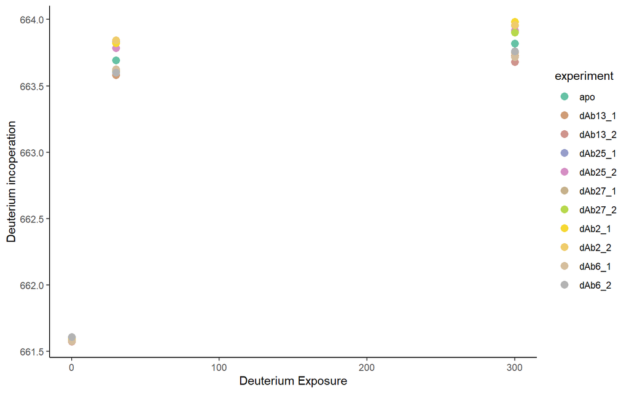

```r
HOIP$Exposure <- HOIP$Exposure * 60 #convert to seconds
filter(HOIP, Sequence == unique(HOIP$Sequence[1])) %>%
    ggplot(aes(x = Exposure,
               y = Center,
               color = factor(State, unique(HOIP$State)))) +
    theme_classic() + geom_point(size = 3) +
    scale_color_manual(values = colorRampPalette(brewer.pal(8, name = "Set2"))(11)) +
    labs(color = "experiment", x = "Deuterium Exposure", y = "Deuterium incoperation")
```

As before we need to convert data to an object of classes `QFeatures` for ease of analysis.

First, we put the data into a `DataFrame` object. Currently, its in long format so we switch to a wide format

```r
HOIP_wide <- pivot_wider(data.frame(HOIP),
                         values_from = Center,
                         names_from = c("Exposure", "State"),
                         id_cols = c("Sequence"))
```

Now remove all columns with only NAs

```r
HOIP_wide <- HOIP_wide[, colSums(is.na(HOIP_wide)) != nrow(HOIP_wide)]
```

The colanmes are not very informative, provide in the format X(time)rep(repliate)cond(condition)

```r
colnames(HOIP_wide)[-c(1)]
```

```
##  [1] "0_apo"       "30_apo"      "300_apo"     "0_dAb13_1"   "30_dAb13_1"
##  [6] "300_dAb13_1" "0_dAb13_2"   "30_dAb13_2"  "300_dAb13_2" "0_dAb25_1"
## [11] "30_dAb25_1"  "300_dAb25_1" "0_dAb25_2"   "30_dAb25_2"  "300_dAb25_2"
## [16] "0_dAb27_1"   "30_dAb27_1"  "300_dAb27_1" "0_dAb27_2"   "30_dAb27_2"
## [21] "300_dAb27_2" "0_dAb2_1"    "30_dAb2_1"   "300_dAb2_1"  "0_dAb2_2"
## [26] "30_dAb2_2"   "300_dAb2_2"  "0_dAb6_1"    "30_dAb6_1"   "300_dAb6_1"
## [31] "0_dAb6_2"    "30_dAb6_2"   "300_dAb6_2"
```

```r
new.colnames <- gsub("0_", "0rep1", paste0("X", colnames(HOIP_wide)[-c(1)]))
new.colnames <- gsub("rep1", "rep1cond", new.colnames)

# remove annoying % signs
new.colnames <- gsub("%", "", new.colnames)

# remove space (NULL could get confusing later and WT is clear)
new.colnames <- gsub(" .*", "", new.colnames)
```

Now, we can provide rownames and convert the data to a `QFeatures` object:

```r
qDF <- parseDeutData(object = DataFrame(HOIP_wide),
                     design = new.colnames,
                     quantcol = 2:34,
                     rownames = HOIP_wide$Sequence)
```

As before, we can produce a heatmap, we perform a simple normalisation for ease of visualisation:

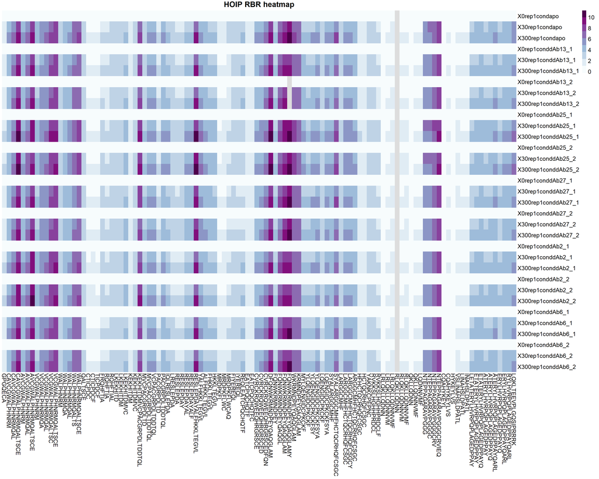

```r
mat <- assay(qDF)
mat <- apply(mat, 2, function(x) x - assay(qDF)[,1])

pheatmap(t(mat),
         cluster_rows = FALSE,
         cluster_cols = FALSE,
         color = brewer.pal(n = 9, name = "BuPu"),
         main = "HOIP RBR heatmap",
         fontsize = 14,
         legend_breaks = c(0, 2, 4, 6,8,10,12, max(assay(qDF))),
         legend_labels = c("0", "2", "4", "6", "8","10", "12", "Incorporation"))
```

Let us first perform a quick test:

```r
res <- differentialUptakeKinetics(object = qDF[,1:33],
                                  feature = rownames(qDF)[[1]][3],
                                  start = list(a = NULL, b = 0.01,  d = NULL),
                                  formula = value ~ a * (1 - exp(-b*(timepoint))) + d)
res@vis+ scale_color_manual(values = colorRampPalette(brewer.pal(8, name = "Set2"))(11))
```

```
## which will replace the existing scale.
```

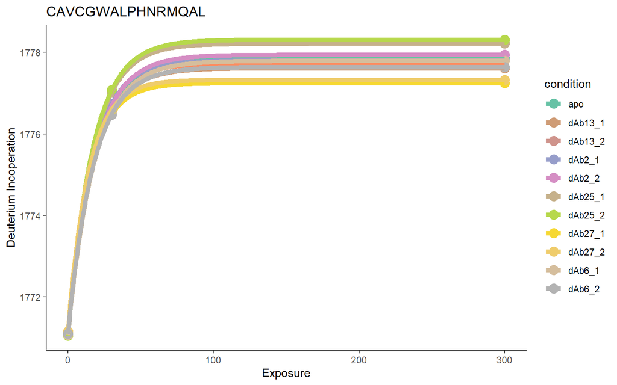

[output not shown]